# Rethinking_Stats_Chapter_12.Rmd

Alex Bayers

04/03/2019

# Easy

### Problem 1

Prior a) will produce more shrinkage, as the lower standard deviation forces each a(tank) closer to 0.

### Problem 2

$$\\y_i \sim Binomial(1, p_i)
\\logit(p_i) \sim \alpha_{GROUP[i]} \> + \> \beta x_i
\\\alpha_{GROUP} \sim Normal(\alpha, \>\sigma)
\\\alpha \sim Normal(0, 10)
\\\beta \sim Normal(0, 1)
\\\sigma \sim HalfCauchy(0, 1)$$

### Problem 3

$$\\y_i \sim Normal(\mu_i, \sigma)
\\\mu_i \sim \alpha_{GROUP[i]} \> + \> \beta x_i
\\\alpha_{GROUP} \sim Normal(\alpha, \>\epsilon)
\\\alpha \sim Normal(0, 10)
\\\beta \sim Normal(0, 1)
\\\sigma \sim HalfCauchy(0, 2)
\\\epsilon \sim HalfCauchy(0, 2)$$

### Problem 4

$$\\T_i \sim Poisson(\mu_i)
\\log(u_i) \sim \alpha + \alpha_{SOCIETY_{[i]}} + \beta_P * log \> P_i
\\\alpha \sim Normal(0, 10)
\\\beta_P \sim Normal(0, 1)
\\\alpha_{SOCIETY} \sim Normal(0, \sigma_{SOCIETY})
\\\sigma_{SOCIETY} \sim HalfCauchy(0,1)$$

# Medium

### Problem 1

```r
library(rethinking)
```

```r
data(reedfrogs)
d <- reedfrogs
d$tank <- 1:nrow(d)

m12.1 <- map2stan(
  alist(
    surv ~ dbinom(density, p),
    logit(p) <- a_tank[tank],
    a_tank[tank]  ~ dnorm(0, 5)
  ),
  data = d
)
```

```
## Computing WAIC
```

```
## Constructing posterior predictions
```

```
## [ 100 / 1000 ]
[ 200 / 1000 ]
[ 300 / 1000 ]
[ 400 / 1000 ]
[ 500 / 1000 ]
[ 600 / 1000 ]
[ 700 / 1000 ]
[ 800 / 1000 ]
[ 900 / 1000 ]
[ 1000 / 1000 ]
```

```
## Aggregated binomial counts detected. Splitting to 0/1 outcome for WAIC calculation.
```

```r
precis(m12.1, depth = 2)
```

```
##             Mean StdDev lower 0.89 upper 0.89 n_eff Rhat
## a_tank[1]   2.46   1.10       0.73       3.95  1600    1
## a_tank[2]   5.68   2.74       1.78       9.90   860    1
## a_tank[3]   0.94   0.77      -0.28       2.12  2543    1
## a_tank[4]   5.73   2.70       1.80       9.76   990    1
## a_tank[5]   2.53   1.22       0.65       4.37  1359    1
## a_tank[6]   2.49   1.09       0.84       4.20  1748    1
## a_tank[7]   5.59   2.58       1.72       9.09   866    1
## a_tank[8]   2.54   1.16       0.71       4.16  1197    1
## a_tank[9]  -0.45   0.65      -1.52       0.48  2286    1
## a_tank[10]  2.51   1.15       0.71       4.12  1497    1
## a_tank[11]  0.95   0.74      -0.26       2.06  1836    1
## a_tank[12]  0.43   0.71      -0.65       1.60  2032    1
## a_tank[13]  0.93   0.72      -0.20       2.03  2863    1
## a_tank[14] -0.01   0.65      -1.07       0.97  2213    1
## a_tank[15]  2.56   1.22       0.68       4.35  1206    1
## a_tank[16]  2.53   1.16       0.77       4.42  1710    1
## a_tank[17]  3.47   1.12       1.95       5.35  1020    1
## a_tank[18]  2.61   0.79       1.32       3.71  1465    1
## a_tank[19]  2.09   0.63       1.06       3.03  1412    1
## a_tank[20]  6.43   2.52       2.99      10.27  1042    1
## a_tank[21]  2.62   0.82       1.39       3.85  1523    1
## a_tank[22]  2.62   0.78       1.40       3.81  1557    1
## a_tank[23]  2.64   0.82       1.44       3.93  1894    1
## a_tank[24]  1.74   0.59       0.73       2.61  1687    1
## a_tank[25] -1.20   0.45      -1.92      -0.51  1648    1
## a_tank[26]  0.09   0.41      -0.54       0.76  2212    1
## a_tank[27] -1.74   0.57      -2.57      -0.85  1854    1
## a_tank[28] -0.59   0.41      -1.26       0.02  3160    1
## a_tank[29]  0.06   0.39      -0.56       0.66  2460    1
## a_tank[30]  1.46   0.52       0.71       2.39  2290    1
## a_tank[31] -0.78   0.43      -1.54      -0.16  3057    1
## a_tank[32] -0.42   0.45      -1.16       0.24  2901    1
## a_tank[33]  3.80   1.10       2.10       5.47  1128    1
## a_tank[34]  2.98   0.75       1.73       4.07  1301    1
## a_tank[35]  2.96   0.74       1.85       4.05  1680    1
## a_tank[36]  2.13   0.58       1.20       3.04  3186    1
## a_tank[37]  2.11   0.55       1.18       2.93  1454    1
## a_tank[38]  6.67   2.52       3.37      10.66   978    1
## a_tank[39]  2.98   0.78       1.63       4.04  2201    1
## a_tank[40]  2.49   0.65       1.41       3.39  1635    1
## a_tank[41] -2.13   0.57      -3.04      -1.30  1581    1
## a_tank[42] -0.67   0.35      -1.21      -0.12  2238    1
## a_tank[43] -0.56   0.34      -1.08      -0.02  1955    1
## a_tank[44] -0.41   0.37      -1.01       0.17  2573    1
## a_tank[45]  0.54   0.34      -0.03       1.06  2321    1
## a_tank[46] -0.66   0.36      -1.22      -0.06  3166    1
## a_tank[47]  2.15   0.57       1.20       2.98  1669    1
## a_tank[48] -0.06   0.34      -0.58       0.53  2550    1
```

```r
m12.2 <- map2stan(
  alist(
    surv ~ dbinom(density, p),
    logit(p) <- a_tank[tank],
    a_tank[tank]  ~ dnorm(a, sigma),
    a ~ dnorm(0, 1),
    sigma ~ dcauchy(0, 1)
  ),
  data = d,
  iter = 4000,
  chains = 4
)
```

```
## Computing WAIC
```

```
## Constructing posterior predictions
```

```
## [ 800 / 8000 ]
[ 1600 / 8000 ]
[ 2400 / 8000 ]
[ 3200 / 8000 ]
[ 4000 / 8000 ]
[ 4800 / 8000 ]
[ 5600 / 8000 ]
[ 6400 / 8000 ]
[ 7200 / 8000 ]
[ 8000 / 8000 ]
```

```
## Aggregated binomial counts detected. Splitting to 0/1 outcome for WAIC calculation.
```

```r
precis(m12.2, depth = 2)
```

```
##             Mean StdDev lower 0.89 upper 0.89 n_eff Rhat
## a_tank[1]   2.12   0.86       0.77       3.45  9605    1
## a_tank[2]   3.05   1.12       1.36       4.85  6876    1
## a_tank[3]   0.99   0.68      -0.07       2.06 10121    1
## a_tank[4]   3.07   1.11       1.37       4.83  7230    1
## a_tank[5]   2.14   0.87       0.82       3.51  8446    1
## a_tank[6]   2.13   0.86       0.86       3.51  8791    1
## a_tank[7]   3.06   1.11       1.38       4.83  7253    1
## a_tank[8]   2.11   0.86       0.71       3.42  8810    1
## a_tank[9]  -0.18   0.63      -1.11       0.87 10227    1
## a_tank[10]  2.11   0.84       0.79       3.41  9932    1
## a_tank[11]  0.99   0.67      -0.08       2.04  9150    1
## a_tank[12]  0.58   0.64      -0.43       1.61  9087    1
## a_tank[13]  0.99   0.67      -0.12       2.01  9604    1
## a_tank[14]  0.19   0.61      -0.77       1.16 10699    1
## a_tank[15]  2.12   0.87       0.67       3.40  9196    1
## a_tank[16]  2.12   0.86       0.79       3.46  9394    1
## a_tank[17]  2.90   0.77       1.69       4.07  7821    1
## a_tank[18]  2.39   0.67       1.35       3.45  8491    1
## a_tank[19]  2.00   0.59       1.00       2.85  9619    1
## a_tank[20]  3.66   1.02       2.05       5.21  6914    1
## a_tank[21]  2.38   0.65       1.33       3.38  9094    1
## a_tank[22]  2.39   0.67       1.31       3.40  8426    1
## a_tank[23]  2.39   0.66       1.38       3.43  9147    1
## a_tank[24]  1.70   0.53       0.85       2.52  8863    1
## a_tank[25] -1.00   0.44      -1.75      -0.35 11073    1
## a_tank[26]  0.16   0.40      -0.48       0.79 11198    1
## a_tank[27] -1.43   0.49      -2.17      -0.61  8865    1
## a_tank[28] -0.48   0.41      -1.12       0.18 12306    1
## a_tank[29]  0.17   0.40      -0.49       0.81 10720    1
## a_tank[30]  1.43   0.48       0.66       2.19 10330    1
## a_tank[31] -0.64   0.41      -1.27       0.04 10004    1
## a_tank[32] -0.30   0.41      -0.99       0.31  9996    1
## a_tank[33]  3.19   0.77       2.03       4.42  6773    1
## a_tank[34]  2.70   0.64       1.70       3.71  8846    1
## a_tank[35]  2.68   0.63       1.67       3.62  9373    1
## a_tank[36]  2.06   0.51       1.23       2.82 10250    1
## a_tank[37]  2.05   0.50       1.25       2.83 11188    1
## a_tank[38]  3.89   0.98       2.38       5.39  6531    1
## a_tank[39]  2.71   0.64       1.75       3.75  7079    1
## a_tank[40]  2.36   0.57       1.42       3.18  9264    1
## a_tank[41] -1.81   0.47      -2.49      -0.99 10082    1
## a_tank[42] -0.57   0.34      -1.12      -0.02  9748    1
## a_tank[43] -0.46   0.34      -1.01       0.08 10673    1
## a_tank[44] -0.34   0.34      -0.86       0.22 10346    1
## a_tank[45]  0.58   0.35       0.02       1.12  9962    1
## a_tank[46] -0.57   0.35      -1.16      -0.04 10562    1
## a_tank[47]  2.05   0.50       1.24       2.82  9930    1
## a_tank[48]  0.00   0.34      -0.53       0.55 11043    1
## a           1.30   0.25       0.90       1.71  7257    1
## sigma       1.62   0.22       1.27       1.96  3806    1
```

```r
compare(m12.1, m12.2)
```

```
##         WAIC pWAIC dWAIC weight    SE  dSE
## m12.2 1009.6  37.7   0.0      1 37.92   NA
## m12.1 1022.4  49.0  12.8      0 42.82 6.44
```

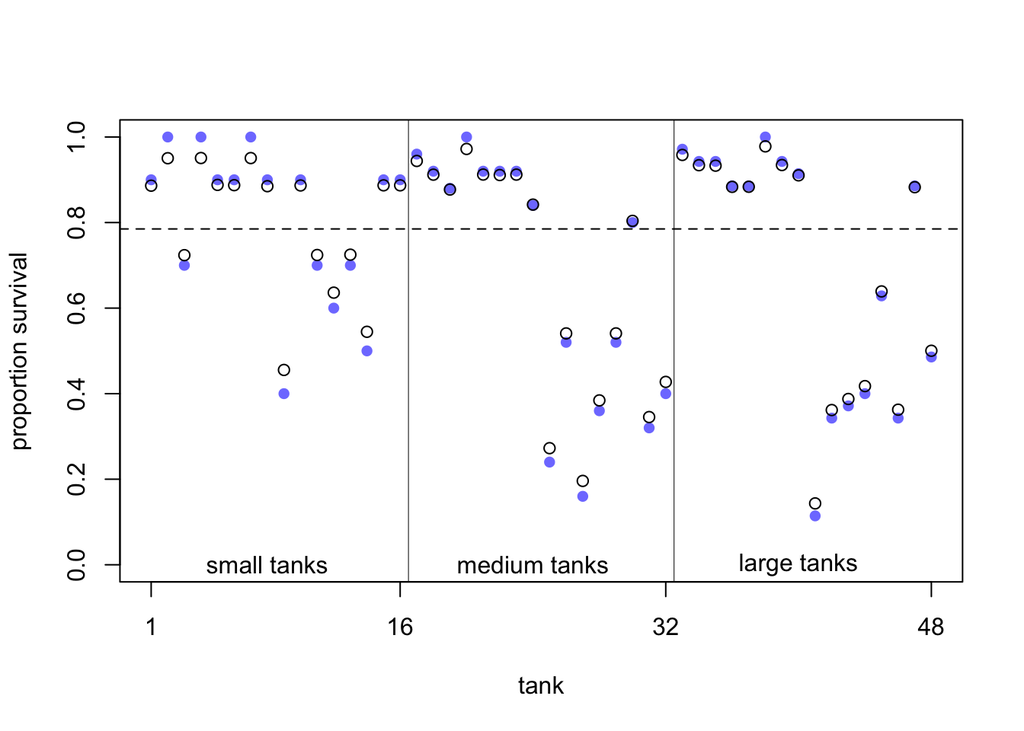

```r
#extract STAN samples
post <- extract.samples(m12.2)

d$propsurv.est <- logistic(apply(post$a_tank, 2, median))

#display raw proportions
plot(d$propsurv, ylim = c(0, 1), pch = 16, xaxt = "n", xlab = "tank", ylab= "proportion survival", col = rangi2)
axis(1, at = c(1, 16, 32, 48), labels = c(1, 16, 32, 48))

#overlay posterior medians
points(d$propsurv.est)

#mark posterior median probability across tanks
abline(h=logistic(median(post$a)), lty = 2)

#draw vertical dividers
abline(v=16.5, lwd = 0.5)
abline(v=32.5, lwd = 0.5)
text(8, 0, "small tanks")
text(16+8, 0, "medium tanks")
text(32+8, 0, "large tanks")
```

```r
d$predbool <- ifelse(d$pred == "pred", 1, 0)
m12.3 <- map2stan(
  alist(
    surv ~ dbinom(density, p),
    logit(p) <- a_tank[tank] + bp*predbool,
    a_tank[tank]  ~ dnorm(a, sigma),
    a ~ dnorm(0, 1),
    sigma ~ dcauchy(0, 1),
    bp ~ dnorm(0, 10)
  ),
  data = d,
  iter = 4000,
  chains = 4
)
```

```
## Computing WAIC
```

```
## Constructing posterior predictions
```

```
## [ 800 / 8000 ]
[ 1600 / 8000 ]
[ 2400 / 8000 ]
[ 3200 / 8000 ]
[ 4000 / 8000 ]
[ 4800 / 8000 ]
[ 5600 / 8000 ]
[ 6400 / 8000 ]
[ 7200 / 8000 ]
[ 8000 / 8000 ]
```

```
## Aggregated binomial counts detected. Splitting to 0/1 outcome for WAIC calculation.
```

```r
precis(m12.3, depth = 2)
```

```
##             Mean StdDev lower 0.89 upper 0.89 n_eff Rhat
## a_tank[1]   2.50   0.71       1.32       3.60 11337    1
## a_tank[2]   2.98   0.76       1.76       4.17  8722    1
## a_tank[3]   1.71   0.63       0.74       2.72  9645    1
## a_tank[4]   2.97   0.74       1.73       4.05  7632    1
## a_tank[5]   2.50   0.69       1.39       3.58  9195    1
## a_tank[6]   2.50   0.70       1.43       3.61  9774    1
## a_tank[7]   2.97   0.75       1.76       4.12  7863    1
## a_tank[8]   2.50   0.69       1.33       3.51  8753    1
## a_tank[9]   2.28   0.58       1.32       3.18  3862    1
## a_tank[10]  3.63   0.65       2.64       4.70  4104    1
## a_tank[11]  3.06   0.59       2.12       3.99  3641    1
## a_tank[12]  2.80   0.59       1.83       3.70  3675    1
## a_tank[13]  3.06   0.59       2.13       4.01  3606    1
## a_tank[14]  2.54   0.58       1.63       3.49  4015    1
## a_tank[15]  3.63   0.65       2.52       4.61  3938    1
## a_tank[16]  3.64   0.63       2.64       4.65  3584    1
## a_tank[17]  2.90   0.62       1.91       3.86 11058    1
## a_tank[18]  2.56   0.57       1.66       3.47 12214    1
## a_tank[19]  2.28   0.53       1.45       3.13 10619    1
## a_tank[20]  3.29   0.68       2.25       4.39  6962    1
## a_tank[21]  2.56   0.57       1.66       3.46 11681    1
## a_tank[22]  2.56   0.56       1.67       3.46 11751    1
## a_tank[23]  2.57   0.57       1.65       3.44 11568    1
## a_tank[24]  2.02   0.51       1.20       2.82 12815    1
## a_tank[25]  1.64   0.50       0.89       2.48  2539    1
## a_tank[26]  2.60   0.47       1.85       3.34  2267    1
## a_tank[27]  1.32   0.53       0.50       2.17  2935    1
## a_tank[28]  2.08   0.48       1.26       2.80  2564    1
## a_tank[29]  2.61   0.46       1.88       3.34  2400    1
## a_tank[30]  3.60   0.50       2.81       4.39  2505    1
## a_tank[31]  1.94   0.48       1.13       2.66  2464    1
## a_tank[32]  2.21   0.47       1.44       2.95  2406    1
## a_tank[33]  3.07   0.58       2.09       3.91  8934    1
## a_tank[34]  2.77   0.54       1.94       3.66 11526    1
## a_tank[35]  2.76   0.54       1.92       3.61  9240    1
## a_tank[36]  2.27   0.47       1.53       3.03 12863    1
## a_tank[37]  2.27   0.47       1.55       3.03 13465    1
## a_tank[38]  3.43   0.66       2.38       4.42  7532    1
## a_tank[39]  2.77   0.54       1.93       3.62 10537    1
## a_tank[40]  2.50   0.52       1.69       3.34 11020    1
## a_tank[41]  1.00   0.50       0.19       1.80  2585    1
## a_tank[42]  1.98   0.44       1.27       2.67  2282    1
## a_tank[43]  2.09   0.44       1.42       2.83  2033    1
## a_tank[44]  2.19   0.43       1.53       2.91  2000    1
## a_tank[45]  2.99   0.44       2.28       3.67  2118    1
## a_tank[46]  1.99   0.45       1.28       2.73  2065    1
## a_tank[47]  4.08   0.50       3.24       4.84  2598    1
## a_tank[48]  2.49   0.44       1.79       3.19  2023    1
## a           2.56   0.24       2.18       2.96  1358    1
## sigma       0.82   0.15       0.59       1.04  3094    1
## bp         -2.54   0.32      -3.03      -2.02  1137    1
```

```r
#Now ordered logit
d$large = ifelse(d$size=="large", 1, 0)
d$medium = ifelse(d$size=="medium", 1, 0)

m12.4 <- map2stan(
  alist(
    surv ~ dbinom(density, p),
    logit(p) <- a_tank[tank] +  bl*large + bm*medium,
    a_tank[tank]  ~ dnorm(a, sigma),
    a ~ dnorm(0, 1),
    sigma ~ dcauchy(0, 1),
    bp ~ dnorm(0, 10),
    bl ~ dnorm(0, 10),
    bm ~ dnorm(0, 10)
  ),
  data = d,
  iter = 4000,
  chains = 4
)
```

```
## Computing WAIC
```

```
## Constructing posterior predictions
```

```
## [ 800 / 8000 ]
[ 1600 / 8000 ]
[ 2400 / 8000 ]
[ 3200 / 8000 ]
[ 4000 / 8000 ]
[ 4800 / 8000 ]
[ 5600 / 8000 ]
[ 6400 / 8000 ]
[ 7200 / 8000 ]
[ 8000 / 8000 ]
```

```
## Aggregated binomial counts detected. Splitting to 0/1 outcome for WAIC calculation.
```

```r
precis(m12.4, depth = 2)
```

```
##             Mean StdDev lower 0.89 upper 0.89 n_eff Rhat
## a_tank[1]   2.11   0.87       0.72       3.44  7903    1
## a_tank[2]   3.06   1.12       1.28       4.74  6625    1
## a_tank[3]   1.00   0.66      -0.05       2.05  8899    1
## a_tank[4]   3.03   1.08       1.29       4.66  7306    1
## a_tank[5]   2.12   0.87       0.68       3.39  7788    1
## a_tank[6]   2.12   0.87       0.70       3.43  8041    1
## a_tank[7]   3.05   1.11       1.25       4.71  7279    1
## a_tank[8]   2.12   0.87       0.74       3.48  7834    1
## a_tank[9]  -0.17   0.62      -1.16       0.84 10168    1
## a_tank[10]  2.13   0.88       0.73       3.47  8463    1
## a_tank[11]  0.99   0.67      -0.07       2.07 10353    1
## a_tank[12]  0.58   0.63      -0.41       1.59  9333    1
## a_tank[13]  1.01   0.67      -0.05       2.08  9811    1
## a_tank[14]  0.18   0.62      -0.81       1.18 10444    1
## a_tank[15]  2.12   0.87       0.78       3.50  7775    1
## a_tank[16]  2.13   0.87       0.79       3.51  8577    1
## a_tank[17]  2.89   0.78       1.70       4.10  6806    1
## a_tank[18]  2.39   0.67       1.31       3.41  8637    1
## a_tank[19]  2.00   0.59       1.04       2.89  8400    1
## a_tank[20]  3.65   1.00       2.12       5.21  6926    1
## a_tank[21]  2.40   0.68       1.32       3.46  7587    1
## a_tank[22]  2.40   0.68       1.32       3.40  7720    1
## a_tank[23]  2.38   0.67       1.35       3.42  7903    1
## a_tank[24]  1.69   0.53       0.84       2.51  8846    1
## a_tank[25] -1.00   0.44      -1.70      -0.32  8859    1
## a_tank[26]  0.15   0.40      -0.50       0.79  9166    1
## a_tank[27] -1.43   0.51      -2.20      -0.61  8353    1
## a_tank[28] -0.47   0.41      -1.13       0.16  9705    1
## a_tank[29]  0.16   0.40      -0.51       0.76  9567    1
## a_tank[30]  1.44   0.48       0.70       2.21  8870    1
## a_tank[31] -0.63   0.40      -1.27       0.01  9944    1
## a_tank[32] -0.31   0.40      -0.92       0.36  9473    1
## a_tank[33]  3.18   0.77       2.03       4.43  7351    1
## a_tank[34]  2.70   0.63       1.66       3.65  7776    1
## a_tank[35]  2.70   0.64       1.69       3.68  7814    1
## a_tank[36]  2.05   0.51       1.20       2.82  8511    1
## a_tank[37]  2.06   0.51       1.26       2.86  8895    1
## a_tank[38]  3.90   0.99       2.32       5.37  6214    1
## a_tank[39]  2.70   0.63       1.68       3.66  8034    1
## a_tank[40]  2.33   0.56       1.47       3.22  8130    1
## a_tank[41] -1.81   0.48      -2.57      -1.05  7690    1
## a_tank[42] -0.57   0.35      -1.13      -0.04  8593    1
## a_tank[43] -0.45   0.35      -0.98       0.12  9770    1
## a_tank[44] -0.34   0.35      -0.91       0.20  9526    1
## a_tank[45]  0.58   0.35       0.04       1.16  8656    1
## a_tank[46] -0.57   0.35      -1.13      -0.01  8725    1
## a_tank[47]  2.05   0.50       1.25       2.82  9263    1
## a_tank[48]  0.00   0.34      -0.53       0.54  9421    1
## a           1.30   0.25       0.90       1.69  7463    1
## sigma       1.62   0.22       1.27       1.94  4435    1
## bp          0.05   9.94     -15.86      16.03  9992    1
## bl         -0.13   9.91     -14.96      16.78  8928    1
## bm          0.16  10.07     -16.25      15.82  8991    1
```

```r
#Now ordered logit
d$large = ifelse(d$size=="large", 1, 0)
d$medium = ifelse(d$size=="medium", 1, 0)

m12.5 <- map2stan(
  alist(
    surv ~ dbinom(density, p),
    logit(p) <- a_tank[tank] + bp*predbool + bl*large + bm*medium,
    a_tank[tank]  ~ dnorm(a, sigma),
    a ~ dnorm(0, 1),
    sigma ~ dcauchy(0, 1),
    bp ~ dnorm(0, 3),
    bl ~ dnorm(0, 3),
    bm ~ dnorm(0, 3)
  ),
  data = d,
  iter = 4000,
  chains = 4
)
```

```
## Computing WAIC
```

```
## Constructing posterior predictions
```

```
## [ 800 / 8000 ]
[ 1600 / 8000 ]
[ 2400 / 8000 ]
[ 3200 / 8000 ]
[ 4000 / 8000 ]
[ 4800 / 8000 ]
[ 5600 / 8000 ]
[ 6400 / 8000 ]
[ 7200 / 8000 ]
[ 8000 / 8000 ]
```

```
## Aggregated binomial counts detected. Splitting to 0/1 outcome for WAIC calculation.
```

```r
precis(m12.5, depth = 2)
```

```
##             Mean StdDev lower 0.89 upper 0.89 n_eff Rhat
## a_tank[1]   2.48   0.68       1.42       3.56  9473    1
## a_tank[2]   2.95   0.74       1.77       4.07  8771    1
## a_tank[3]   1.71   0.64       0.66       2.69  9171    1
## a_tank[4]   2.95   0.75       1.79       4.11  7700    1
## a_tank[5]   2.48   0.67       1.45       3.58  9112    1
## a_tank[6]   2.49   0.68       1.39       3.54  9059    1
## a_tank[7]   2.95   0.72       1.72       4.01  8321    1
## a_tank[8]   2.48   0.68       1.42       3.58  9921    1
## a_tank[9]   2.26   0.58       1.34       3.17  3618    1
## a_tank[10]  3.61   0.63       2.60       4.58  3887    1
## a_tank[11]  3.04   0.57       2.11       3.93  3962    1
## a_tank[12]  2.78   0.57       1.83       3.65  3789    1
## a_tank[13]  3.05   0.57       2.12       3.95  3825    1
## a_tank[14]  2.52   0.57       1.62       3.43  3590    1
## a_tank[15]  3.61   0.63       2.64       4.61  4484    1
## a_tank[16]  3.60   0.63       2.58       4.57  3614    1
## a_tank[17]  2.89   0.62       1.93       3.87  9439    1
## a_tank[18]  2.56   0.57       1.59       3.39  9302    1
## a_tank[19]  2.27   0.53       1.38       3.06  9422    1
## a_tank[20]  3.27   0.68       2.18       4.31  8118    1
## a_tank[21]  2.55   0.57       1.63       3.42 11250    1
## a_tank[22]  2.55   0.56       1.67       3.46 10135    1
## a_tank[23]  2.56   0.56       1.68       3.45 10526    1
## a_tank[24]  2.02   0.50       1.19       2.79 11500    1
## a_tank[25]  1.62   0.49       0.88       2.44  2565    1
## a_tank[26]  2.58   0.46       1.89       3.35  2302    1
## a_tank[27]  1.30   0.51       0.49       2.12  2558    1
## a_tank[28]  2.05   0.46       1.35       2.82  2363    1
## a_tank[29]  2.58   0.46       1.85       3.31  2368    1
## a_tank[30]  3.57   0.50       2.77       4.35  2730    1
## a_tank[31]  1.91   0.47       1.14       2.64  2488    1
## a_tank[32]  2.19   0.47       1.49       2.98  2501    1
## a_tank[33]  3.06   0.59       2.11       3.96  8771    1
## a_tank[34]  2.76   0.54       1.91       3.62  9969    1
## a_tank[35]  2.75   0.54       1.91       3.61 11329    1
## a_tank[36]  2.27   0.48       1.49       3.00 11324    1
## a_tank[37]  2.26   0.48       1.50       3.00 10850    1
## a_tank[38]  3.42   0.67       2.41       4.47  7413    1
## a_tank[39]  2.75   0.54       1.93       3.61 10924    1
## a_tank[40]  2.49   0.51       1.65       3.25 10684    1
## a_tank[41]  0.98   0.51       0.18       1.79  2581    1
## a_tank[42]  1.96   0.44       1.26       2.65  2050    1
## a_tank[43]  2.07   0.43       1.38       2.76  2056    1
## a_tank[44]  2.16   0.43       1.49       2.86  2065    1
## a_tank[45]  2.97   0.43       2.30       3.67  2013    1
## a_tank[46]  1.96   0.44       1.26       2.65  2118    1
## a_tank[47]  4.05   0.50       3.29       4.84  2482    1
## a_tank[48]  2.46   0.42       1.80       3.13  1875    1
## a           2.54   0.23       2.18       2.93  1326    1
## sigma       0.82   0.14       0.58       1.02  3251    1
## bp         -2.51   0.30      -3.00      -2.03  1096    1
## bl          0.00   3.01      -5.13       4.46 17293    1
## bm          0.00   3.02      -4.72       4.99 18412    1
```

```r
#Now interactions
m12.6 <- map2stan(
  alist(
    surv ~ dbinom(density, p),
    logit(p) <- a_tank[tank] + bp*predbool + bl*large + bm*medium + bpl*predbool*large + bpm*predbool*medium,
    a_tank[tank]  ~ dnorm(a, sigma),
    a ~ dnorm(0, 1),
    sigma ~ dcauchy(0, 1),
    bp ~ dnorm(0, 10),
    bl ~ dnorm(0, 3),
    bm ~ dnorm(0, 3),
    bpl ~ dnorm(0, 3),
    bpm ~ dnorm(0, 3)
  ),
  data = d,
  iter = 4000,
  chains = 4
)
```

```
## Computing WAIC
```

```
## Constructing posterior predictions
```

```
## [ 800 / 8000 ]
[ 1600 / 8000 ]
[ 2400 / 8000 ]
[ 3200 / 8000 ]
[ 4000 / 8000 ]
[ 4800 / 8000 ]
[ 5600 / 8000 ]
[ 6400 / 8000 ]
[ 7200 / 8000 ]
[ 8000 / 8000 ]
```

```
## Aggregated binomial counts detected. Splitting to 0/1 outcome for WAIC calculation.
```

```r
precis(m12.6, depth = 2)
```

```
##             Mean StdDev lower 0.89 upper 0.89 n_eff Rhat
## a_tank[1]   2.50   0.68       1.36       3.54  8142    1
## a_tank[2]   2.96   0.73       1.79       4.12  8000    1
## a_tank[3]   1.72   0.63       0.71       2.69  8795    1
## a_tank[4]   2.96   0.74       1.74       4.06  8508    1
## a_tank[5]   2.49   0.67       1.43       3.54  9785    1
## a_tank[6]   2.49   0.67       1.41       3.55  9940    1
## a_tank[7]   2.96   0.73       1.78       4.09  8516    1
## a_tank[8]   2.50   0.68       1.43       3.58 10280    1
## a_tank[9]   2.29   0.57       1.44       3.25  3754    1
## a_tank[10]  3.63   0.62       2.64       4.61  3893    1
## a_tank[11]  3.07   0.58       2.15       3.98  3519    1
## a_tank[12]  2.80   0.57       1.90       3.75  3554    1
## a_tank[13]  3.06   0.57       2.14       3.96  4107    1
## a_tank[14]  2.55   0.56       1.67       3.47  3978    1
## a_tank[15]  3.62   0.62       2.63       4.58  3795    1
## a_tank[16]  3.63   0.64       2.64       4.70  4139    1
## a_tank[17]  2.90   0.62       1.85       3.81  9764    1
## a_tank[18]  2.57   0.57       1.61       3.40  9750    1
## a_tank[19]  2.28   0.53       1.42       3.12 10139    1
## a_tank[20]  3.28   0.68       2.25       4.39  7418    1
## a_tank[21]  2.56   0.56       1.60       3.39  8687    1
## a_tank[22]  2.56   0.56       1.61       3.38 10732    1
## a_tank[23]  2.57   0.57       1.58       3.40 11331    1
## a_tank[24]  2.02   0.49       1.23       2.78 11764    1
## a_tank[25]  1.65   0.49       0.92       2.47  2888    1
## a_tank[26]  2.61   0.46       1.86       3.33  2585    1
## a_tank[27]  1.34   0.51       0.49       2.11  3027    1
## a_tank[28]  2.08   0.46       1.39       2.87  2694    1
## a_tank[29]  2.61   0.46       1.89       3.32  2453    1
## a_tank[30]  3.59   0.49       2.84       4.43  2800    1
## a_tank[31]  1.95   0.47       1.22       2.72  2682    1
## a_tank[32]  2.22   0.46       1.53       3.00  2668    1
## a_tank[33]  3.07   0.59       2.16       4.04 10259    1
## a_tank[34]  2.77   0.55       1.84       3.57 11257    1
## a_tank[35]  2.77   0.55       1.90       3.66 10599    1
## a_tank[36]  2.27   0.47       1.48       2.99 10501    1
## a_tank[37]  2.27   0.48       1.52       3.06 11700    1
## a_tank[38]  3.42   0.65       2.33       4.36  6936    1
## a_tank[39]  2.77   0.54       1.94       3.64 11010    1
## a_tank[40]  2.50   0.51       1.72       3.36 11927    1
## a_tank[41]  1.01   0.50       0.21       1.80  2867    1
## a_tank[42]  1.99   0.44       1.27       2.68  2295    1
## a_tank[43]  2.10   0.43       1.44       2.81  2422    1
## a_tank[44]  2.20   0.44       1.49       2.88  2382    1
## a_tank[45]  2.99   0.44       2.30       3.68  2433    1
## a_tank[46]  1.99   0.44       1.32       2.73  2279    1
## a_tank[47]  4.09   0.50       3.24       4.85  2717    1
## a_tank[48]  2.49   0.42       1.85       3.18  2156    1
## a           2.56   0.24       2.20       2.95  1473    1
## sigma       0.81   0.14       0.59       1.04  3127    1
## bp         -2.54   0.31      -3.05      -2.06  1279    1
## bl          0.02   2.98      -4.61       4.85 15159    1
## bm          0.01   3.03      -4.89       4.91 15270    1
## bpl        -0.01   3.06      -4.65       5.06 15032    1
## bpm         0.03   2.99      -4.53       4.94 14600    1
```

```r
compare(m12.1, m12.2, m12.3, m12.4, m12.5, m12.6)
```

```
##         WAIC pWAIC dWAIC weight    SE   dSE
## m12.6 1001.2  28.6   0.0   0.35 37.31    NA
## m12.3 1001.4  28.8   0.1   0.33 37.33  0.21
## m12.5 1001.4  28.7   0.2   0.32 37.23  0.20
## m12.2 1009.6  37.7   8.3   0.01 37.92  6.73
## m12.4 1010.2  38.0   9.0   0.00 37.93  6.80
## m12.1 1022.4  49.0  21.2   0.00 42.82 10.34
```

```r
coeftab(m12.3, m12.5, m12.6, se = TRUE)
```

```
##               m12.3   m12.5   m12.6
## a_tank[1]        2.50    2.48    2.50
## a_tank[2]        2.98    2.95    2.96
## a_tank[3]        1.71    1.71    1.72
## a_tank[4]        2.97    2.95    2.96
## a_tank[5]        2.50    2.48    2.49
## a_tank[6]        2.50    2.49    2.49
## a_tank[7]        2.97    2.95    2.96
## a_tank[8]        2.50    2.48    2.50
## a_tank[9]        2.28    2.26    2.29
## a_tank[10]       3.63    3.61    3.63
## a_tank[11]       3.06    3.04    3.07
## a_tank[12]       2.80    2.78    2.80
## a_tank[13]       3.06    3.05    3.06
## a_tank[14]       2.54    2.52    2.55
## a_tank[15]       3.63    3.61    3.62
## a_tank[16]       3.64    3.60    3.63
## a_tank[17]       2.90    2.89    2.90
## a_tank[18]       2.56    2.56    2.57
## a_tank[19]       2.28    2.27    2.28
## a_tank[20]       3.29    3.27    3.28
## a_tank[21]       2.56    2.55    2.56
## a_tank[22]       2.56    2.55    2.56
## a_tank[23]       2.57    2.56    2.57
## a_tank[24]       2.02    2.02    2.02
## a_tank[25]       1.64    1.62    1.65
## a_tank[26]       2.60    2.58    2.61
## a_tank[27]       1.32    1.30    1.34
## a_tank[28]       2.08    2.05    2.08
## a_tank[29]       2.61    2.58    2.61
## a_tank[30]       3.60    3.57    3.59
## a_tank[31]       1.94    1.91    1.95
## a_tank[32]       2.21    2.19    2.22
## a_tank[33]       3.07    3.06    3.07
## a_tank[34]       2.77    2.76    2.77
## a_tank[35]       2.76    2.75    2.77
## a_tank[36]       2.27    2.27    2.27
## a_tank[37]       2.27    2.26    2.27
## a_tank[38]       3.43    3.42    3.42
## a_tank[39]       2.77    2.75    2.77
```

[output cut: 57 more lines]

```
## a_tank[42].se    0.44    0.44    0.44
## a_tank[43].se    0.44    0.43    0.43
## a_tank[44].se    0.43    0.43    0.44
## a_tank[45].se    0.44    0.43    0.44
## a_tank[46].se    0.45    0.44    0.44
## a_tank[47].se     0.5     0.5     0.5
## a_tank[48].se    0.44    0.42    0.42
## a.se             0.24    0.23    0.24
## sigma.se         0.15    0.14    0.14
## bp.se            0.32    0.30    0.31
## bl.se              NA    3.01    2.98
## bm.se              NA    3.02    3.03
## bpl.se             NA      NA    3.06
## bpm.se             NA      NA    2.99
## nobs               48      48      48
```

Looking at the model, the addition of predation substantially shrinks the variance (sigma) of a(t). Effectively, our parameters were overdispersed because of the omitted variable bias.

###Problem 2 Interestingly, despite quite a wide standard error bar on the coefficients in models 12.5 and 12.6, the difference in WAIC is not very large between models 12.3, 12.5, and 12.6. Looking at the effective number of parameters, there are scarcely any more free parameters in m12.5 versus m12.6 - (28.7 and 28.8 versus 28.6). I think there are fewer effective parameters because of the large number of varying coefficients - by adding additional shrinkage from the new variables this can easily offset the additional variables.

###Problem 3

```r
m12.7 <- map2stan(
  alist(
    surv ~ dbinom(density, p),
    logit(p) <- a_tank[tank],
    a_tank[tank]  ~ dcauchy(a, sigma),
    a ~ dnorm(0, 1),
    sigma ~ dcauchy(0, 1)
  ),
  data = d,
  iter = 6000,
  chains = 4,
  control = list(max_treedepth=15)
)
```

```
## Computing WAIC
```

```
## Constructing posterior predictions
```

```
## [ 1200 / 12000 ]
[ 2400 / 12000 ]
[ 3600 / 12000 ]
[ 4800 / 12000 ]
[ 6000 / 12000 ]
[ 7200 / 12000 ]
[ 8400 / 12000 ]
[ 9600 / 12000 ]
[ 10800 / 12000 ]
[ 12000 / 12000 ]
```

```
## Aggregated binomial counts detected. Splitting to 0/1 outcome for WAIC calculation.
```

```r
precis(m12.7, depth = 2)
```

```
##             Mean StdDev lower 0.89 upper 0.89 n_eff Rhat
## a_tank[1]   2.01   0.84       0.70       3.24  8875 1.00
## a_tank[2]   8.17  37.83       0.76      10.27   382 1.01
## a_tank[3]   1.11   0.61       0.17       2.09 12539 1.00
## a_tank[4]   7.93  21.67       0.80      11.39   215 1.02
## a_tank[5]   2.01   0.87       0.69       3.26  8593 1.00
## a_tank[6]   2.02   0.87       0.75       3.28  5129 1.00
## a_tank[7]   6.96  14.76       0.69      11.33   626 1.00
## a_tank[8]   2.03   0.85       0.77       3.30  7787 1.00
## a_tank[9]  -0.08   0.68      -1.10       1.05 13621 1.00
## a_tank[10]  2.02   0.88       0.70       3.29  6975 1.00
## a_tank[11]  1.10   0.61       0.19       2.09 12180 1.00
## a_tank[12]  0.73   0.62      -0.26       1.70 13150 1.00
## a_tank[13]  1.11   0.61       0.07       2.01 14183 1.00
## a_tank[14]  0.35   0.63      -0.66       1.34 13421 1.00
## a_tank[15]  2.01   0.84       0.73       3.22  8561 1.00
## a_tank[16]  2.02   0.86       0.73       3.28  6638 1.00
## a_tank[17]  2.85   0.93       1.54       4.25  7902 1.00
## a_tank[18]  2.27   0.66       1.27       3.29  8690 1.00
## a_tank[19]  1.92   0.56       1.04       2.76 11628 1.00
## a_tank[20] 22.57  71.16       1.25      24.99    73 1.05
## a_tank[21]  2.27   0.66       1.24       3.24  9987 1.00
## a_tank[22]  2.27   0.66       1.22       3.23  9358 1.00
## a_tank[23]  2.26   0.65       1.26       3.26 10544 1.00
## a_tank[24]  1.66   0.47       0.90       2.40 12042 1.00
## a_tank[25] -1.06   0.47      -1.79      -0.30 12587 1.00
## a_tank[26]  0.23   0.40      -0.40       0.88 14346 1.00
## a_tank[27] -1.58   0.55      -2.43      -0.70 14268 1.00
## a_tank[28] -0.46   0.43      -1.16       0.21 13646 1.00
## a_tank[29]  0.23   0.41      -0.43       0.87 13620 1.00
## a_tank[30]  1.45   0.45       0.71       2.12 12873 1.00
## a_tank[31] -0.64   0.44      -1.32       0.05 14438 1.00
## a_tank[32] -0.28   0.42      -0.95       0.38 14332 1.00
## a_tank[33]  3.26   1.00       1.80       4.68  6883 1.00
## a_tank[34]  2.62   0.70       1.54       3.67  8456 1.00
## a_tank[35]  2.60   0.68       1.59       3.64  8784 1.00
## a_tank[36]  1.97   0.48       1.19       2.71 11034 1.00
## a_tank[37]  1.98   0.49       1.22       2.74 11170 1.00
## a_tank[38] 20.15  79.58       1.73      21.69   156 1.02
## a_tank[39]  2.61   0.69       1.54       3.64  9929 1.00
## a_tank[40]  2.23   0.55       1.40       3.11 11110 1.00
## a_tank[41] -1.99   0.53      -2.82      -1.15 13806 1.00
## a_tank[42] -0.57   0.36      -1.14       0.01 14142 1.00
## a_tank[43] -0.45   0.36      -1.01       0.14 13647 1.00
## a_tank[44] -0.32   0.36      -0.92       0.22 14367 1.00
## a_tank[45]  0.65   0.35       0.10       1.20 15087 1.00
## a_tank[46] -0.57   0.36      -1.12       0.03 14538 1.00
## a_tank[47]  1.98   0.49       1.18       2.71 10074 1.00
## a_tank[48]  0.05   0.35      -0.51       0.59 14922 1.00
## a           1.41   0.29       0.95       1.88  7984 1.00
## sigma       1.03   0.23       0.66       1.38  7039 1.00
```

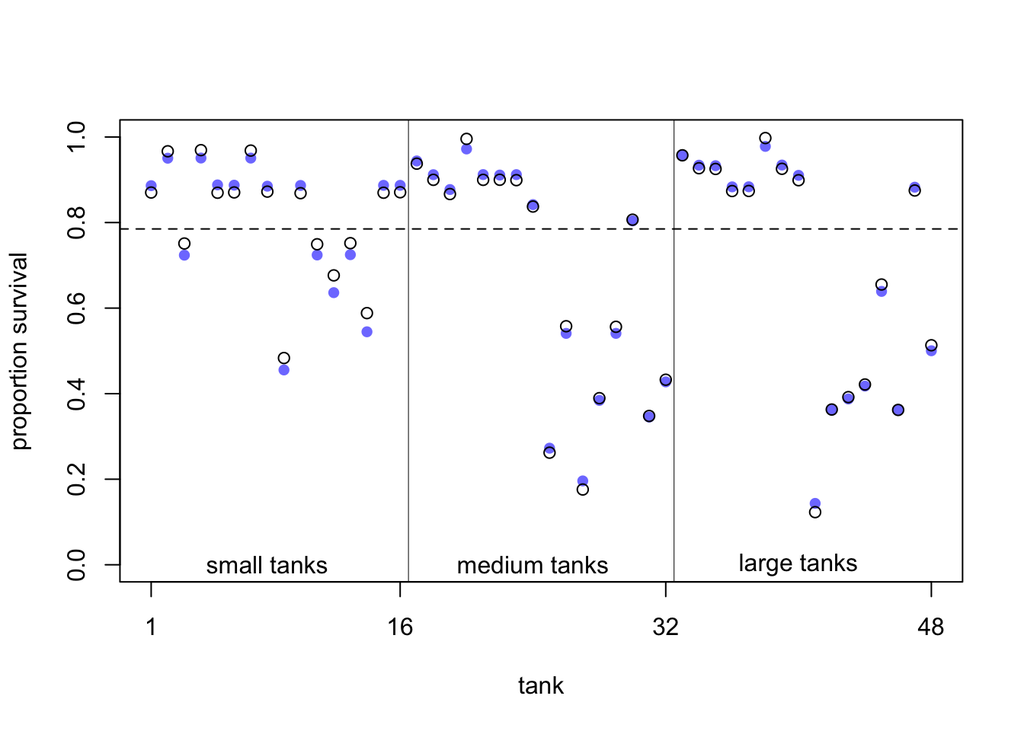

```r
post.new <- extract.samples(m12.7)

d$propsurv.new <- logistic(apply(post.new$a_tank, 2, median))

#display normal proportions
plot(d$propsurv.est, ylim = c(0, 1), pch = 16, xaxt = "n", xlab = "tank", ylab= "proportion survival", col = rangi2)
axis(1, at = c(1, 16, 32, 48), labels = c(1, 16, 32, 48))

#overlay cauchy medians
points(d$propsurv.new)

#mark posterior median probability across tanks
abline(h=logistic(median(post$a)), lty = 2)

#draw vertical dividers
abline(v=16.5, lwd = 0.5)
abline(v=32.5, lwd = 0.5)
text(8, 0, "small tanks")
text(16+8, 0, "medium tanks")
text(32+8, 0, "large tanks")
```

###Problem 4

```r
data("chimpanzees")
d <- chimpanzees
d$block_id <- d$block

m12.8 <- map2stan(
  alist(
    pulled_left <- dbinom(1, p),
    logit(p) <- a_actor[actor] + a_block[block_id] + (bp+ bpC*condition)*prosoc_left,
    a_actor[actor] ~ dnorm(alpha, sigma_actor),
    a_block[block_id] ~ dnorm(gamma, sigma_block),
    c(alpha, gamma, bp, bpC) ~ dnorm(0, 10),
    c(sigma_actor, sigma_block) ~ dcauchy(0, 1)
  ),
  data = d,
  warmup = 1000,
  iter = 5000,
  chains = 4,
  cores = 4
)
```

```
## Computing WAIC
```

```
## Constructing posterior predictions
```

```
## [ 1600 / 16000 ]
[ 3200 / 16000 ]
[ 4800 / 16000 ]
[ 6400 / 16000 ]
[ 8000 / 16000 ]
[ 9600 / 16000 ]
[ 11200 / 16000 ]
[ 12800 / 16000 ]
[ 14400 / 16000 ]
[ 16000 / 16000 ]
```

```r
precis(m12.8, depth = 2)
```

```
##              Mean StdDev lower 0.89 upper 0.89 n_eff Rhat
## a_actor[1]  -0.78   6.79     -12.40       9.47  1055 1.01
## a_actor[2]   4.70   6.99      -7.53      14.80   860 1.02
## a_actor[3]  -1.08   6.78     -12.56       9.23  1061 1.01
## a_actor[4]  -1.09   6.79     -12.42       9.47  1055 1.01
## a_actor[5]  -0.79   6.78     -12.41       9.52  1062 1.01
## a_actor[6]   0.17   6.79     -11.55      10.32  1050 1.01
## a_actor[7]   1.70   6.79      -9.67      12.29  1056 1.01
## a_block[1]  -0.17   6.78     -10.70      11.17  1058 1.01
## a_block[2]   0.11   6.79      -9.81      12.07  1046 1.01
## a_block[3]   0.12   6.79      -9.99      11.87  1047 1.01
## a_block[4]   0.07   6.79     -10.16      11.73  1049 1.01
## a_block[5]   0.01   6.79     -10.07      11.79  1049 1.01
## a_block[6]   0.20   6.79      -9.81      12.05  1044 1.01
## alpha        0.47   6.81     -11.29      10.44   930 1.02
## gamma        0.05   6.79     -10.06      11.83  1049 1.01
## bp           0.84   0.26       0.47       1.28  1333 1.01
## bpC         -0.15   0.29      -0.61       0.31  2462 1.00
## sigma_actor  2.27   0.92       1.00       3.30  2347 1.00
## sigma_block  0.27   0.17       0.08       0.47   182 1.04
```

The chains are estimated quote poorly; in particular, with low n_eff, because of the high correlation between the two different grand mean parameters.

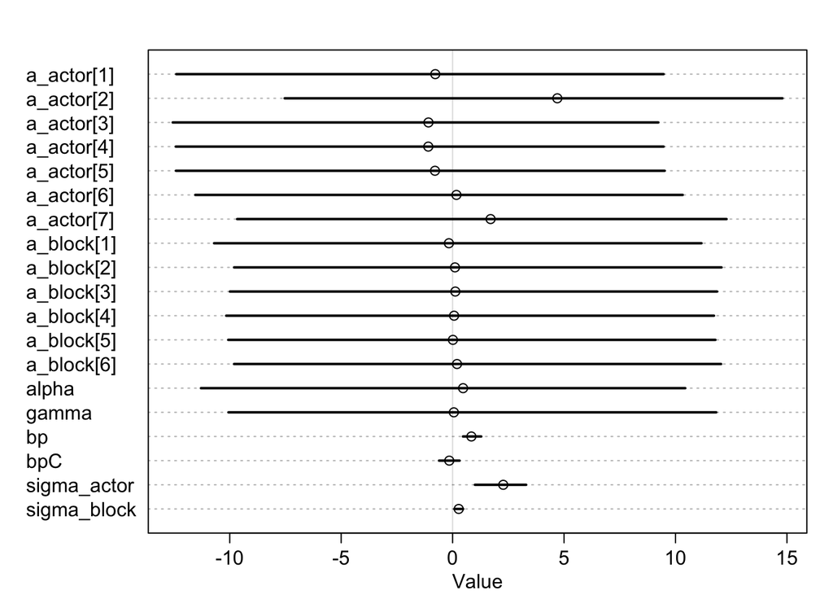

```r
plot(precis(m12.8, depth = 2))
```

```
## Waiting to draw page 2 of 2
```

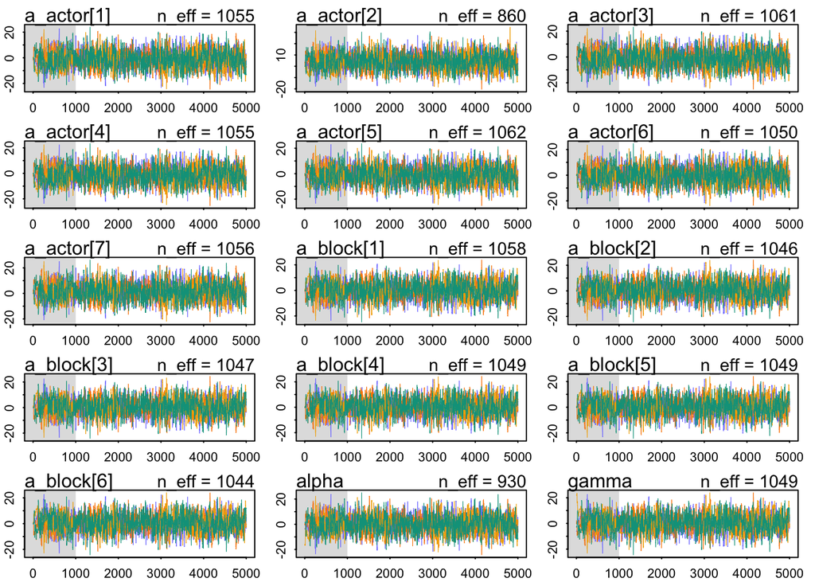

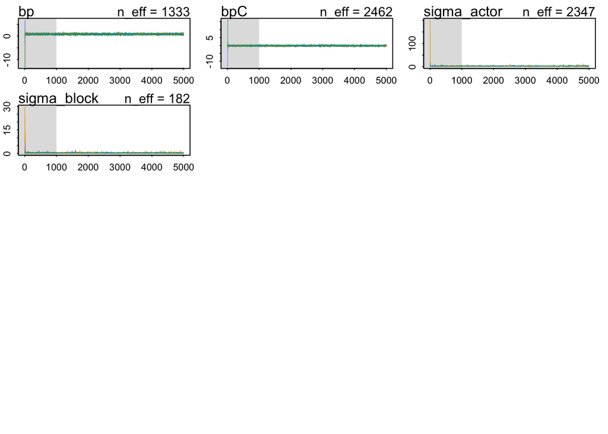

```r
plot(m12.8)
```

#Hard ###Problem 1

```r
data("bangladesh")
d <- bangladesh
d$district_id <- as.integer(as.factor(d$district))

m12.9 <- map2stan(
  alist(
    use.contraception <- dbinom(1, p),
    logit(p) <- a_district[district_id],
    a_district[district_id] ~ dnorm(alpha, sigma_district),
    alpha ~ dnorm(0, 10),
    sigma_district ~ dcauchy(0, 1)
  ),
  data = d,
  warmup = 1000,
  iter = 5000,
  chains = 4,
  cores = 4
)
```

```
## Computing WAIC
```

```
## Constructing posterior predictions
```

```
## [ 1600 / 16000 ]
[ 3200 / 16000 ]
[ 4800 / 16000 ]
[ 6400 / 16000 ]
[ 8000 / 16000 ]
[ 9600 / 16000 ]
[ 11200 / 16000 ]
[ 12800 / 16000 ]
[ 14400 / 16000 ]
[ 16000 / 16000 ]
```

```r
precis(m12.9, depth = 2)
```

```
##                 Mean StdDev lower 0.89 upper 0.89 n_eff Rhat
## a_district[1]  -0.99   0.19      -1.31      -0.70 19046    1
## a_district[2]  -0.59   0.35      -1.16      -0.05 22054    1
## a_district[3]  -0.23   0.51      -1.08       0.55 21647    1
## a_district[4]  -0.19   0.31      -0.68       0.30 22968    1
## a_district[5]  -0.57   0.28      -1.01      -0.12 24208    1
## a_district[6]  -0.82   0.24      -1.20      -0.44 24164    1
## a_district[7]  -0.76   0.37      -1.34      -0.15 23125    1
## a_district[8]  -0.52   0.29      -0.97      -0.06 22787    1
## a_district[9]  -0.71   0.34      -1.24      -0.16 21830    1
## a_district[10] -1.14   0.44      -1.80      -0.43 17593    1
## a_district[11] -1.55   0.43      -2.23      -0.86 12289    1
## a_district[12] -0.61   0.32      -1.14      -0.13 22545    1
## a_district[13] -0.42   0.32      -0.94       0.09 20755    1
## a_district[14]  0.39   0.18       0.10       0.67 20055    1
## a_district[15] -0.56   0.34      -1.12      -0.03 21948    1
## a_district[16] -0.12   0.35      -0.66       0.44 21547    1
## a_district[17] -0.75   0.34      -1.28      -0.20 20761    1
## a_district[18] -0.64   0.26      -1.05      -0.21 24121    1
## a_district[19] -0.50   0.32      -1.02       0.01 19241    1
## a_district[20] -0.48   0.38      -1.07       0.13 21313    1
## a_district[21] -0.50   0.36      -1.09       0.05 23937    1
## a_district[22] -0.97   0.37      -1.54      -0.36 18167    1
## a_district[23] -0.76   0.39      -1.37      -0.15 20350    1
## a_district[24] -1.18   0.43      -1.86      -0.50 13955    1
## a_district[25] -0.28   0.22      -0.63       0.08 22693    1
## a_district[26] -0.52   0.38      -1.14       0.07 23380    1
## a_district[27] -1.18   0.30      -1.65      -0.68 17952    1
## a_district[28] -0.97   0.27      -1.39      -0.51 20032    1
## a_district[29] -0.80   0.31      -1.28      -0.29 20453    1
## a_district[30] -0.14   0.24      -0.51       0.24 21766    1
## a_district[31] -0.30   0.30      -0.78       0.17 21366    1
## a_district[32] -0.98   0.35      -1.54      -0.42 17501    1
## a_district[33] -0.42   0.38      -1.02       0.19 24111    1
## a_district[34]  0.27   0.30      -0.19       0.75 18406    1
## a_district[35] -0.13   0.26      -0.56       0.25 22063    1
## a_district[36] -0.58   0.36      -1.17      -0.01 20701    1
## a_district[37] -0.23   0.39      -0.84       0.40 22603    1
## a_district[38] -0.72   0.39      -1.32      -0.09 20807    1
## a_district[39] -0.20   0.31      -0.69       0.31 23465    1
```

[output cut: 8 more lines]

```
## a_district[48] -0.08   0.27      -0.51       0.35 21847    1
## a_district[49] -0.87   0.50      -1.63      -0.05 18310    1
## a_district[50] -0.31   0.35      -0.84       0.26 22558    1
## a_district[51] -0.28   0.28      -0.71       0.19 24059    1
## a_district[52] -0.30   0.23      -0.67       0.07 22759    1
## a_district[53] -0.42   0.35      -1.01       0.12 22052    1
## a_district[54] -0.79   0.46      -1.50      -0.05 20804    1
## a_district[55]  0.09   0.26      -0.33       0.51 19687    1
## a_district[56] -1.07   0.35      -1.61      -0.50 17179    1
## a_district[57] -0.30   0.29      -0.76       0.15 21583    1
## a_district[58] -1.01   0.44      -1.69      -0.30 17198    1
## a_district[59] -1.00   0.33      -1.50      -0.46 19966    1
## a_district[60] -1.06   0.30      -1.53      -0.58 18067    1
## alpha          -0.54   0.09      -0.68      -0.39 12174    1
## sigma_district  0.52   0.08       0.39       0.65  5481    1
```

```r
m12.10 <- map2stan(
  alist(
    use.contraception <- dbinom(1, p),
    logit(p) <- a_district[district_id],
    a_district[district_id] ~ dnorm(0, 10)
  ),
  data = d,
  warmup = 1000,
  iter = 5000,
  chains = 4,
  cores = 4
)
```

```
## Computing WAIC
```

```
## Constructing posterior predictions
```

```
## [ 1600 / 16000 ]
[ 3200 / 16000 ]
[ 4800 / 16000 ]
[ 6400 / 16000 ]
[ 8000 / 16000 ]
[ 9600 / 16000 ]
[ 11200 / 16000 ]
[ 12800 / 16000 ]
[ 14400 / 16000 ]
[ 16000 / 16000 ]
```

```r
precis(m12.10, depth = 2)
```

```
##                  Mean StdDev lower 0.89 upper 0.89 n_eff Rhat
## a_district[1]   -1.07   0.21      -1.43      -0.74 23506    1
## a_district[2]   -0.66   0.48      -1.42       0.11 23623    1
## a_district[3]    8.58   5.99       0.10      17.21  9660    1
## a_district[4]    0.00   0.37      -0.60       0.57 26281    1
## a_district[5]   -0.60   0.34      -1.13      -0.05 24208    1
## a_district[6]   -0.90   0.27      -1.32      -0.46 24947    1
## a_district[7]   -1.01   0.54      -1.87      -0.14 24203    1
## a_district[8]   -0.51   0.35      -1.05       0.05 21548    1
## a_district[9]   -0.87   0.46      -1.62      -0.14 20934    1
## a_district[10]  -2.98   1.29      -4.86      -1.05 11774    1
## a_district[11] -10.32   5.55     -17.99      -2.56 10107    1
## a_district[12]  -0.67   0.40      -1.33      -0.05 22051    1
## a_district[13]  -0.35   0.42      -1.01       0.32 25913    1
## a_district[14]   0.53   0.19       0.21       0.82 22355    1
## a_district[15]  -0.59   0.46      -1.32       0.13 24630    1
## a_district[16]   0.21   0.47      -0.54       0.94 23715    1
## a_district[17]  -0.92   0.46      -1.63      -0.17 22034    1
## a_district[18]  -0.68   0.32      -1.17      -0.17 21035    1
## a_district[19]  -0.48   0.41      -1.14       0.16 24255    1
## a_district[20]  -0.43   0.54      -1.30       0.40 23020    1
## a_district[21]  -0.47   0.50      -1.27       0.32 21974    1
## a_district[22]  -1.48   0.58      -2.37      -0.55 18811    1
## a_district[23]  -1.09   0.62      -2.05      -0.09 21744    1
## a_district[24]  -3.04   1.27      -4.89      -1.12 11969    1
## a_district[25]  -0.21   0.24      -0.60       0.19 25342    1
## a_district[26]  -0.50   0.60      -1.44       0.43 22755    1
## a_district[27]  -1.55   0.40      -2.18      -0.93 20384    1
## a_district[28]  -1.15   0.34      -1.67      -0.58 20835    1
## a_district[29]  -0.97   0.40      -1.62      -0.34 23555    1
## a_district[30]  -0.03   0.26      -0.43       0.40 25355    1
## a_district[31]  -0.19   0.36      -0.77       0.36 22557    1
## a_district[32]  -1.41   0.52      -2.24      -0.58 21966    1
## a_district[33]  -0.31   0.56      -1.21       0.57 24044    1
## a_district[34]   0.67   0.36       0.10       1.24 24468    1
## a_district[35]   0.00   0.29      -0.45       0.47 22896    1
## a_district[36]  -0.64   0.52      -1.50       0.18 26246    1
## a_district[37]   0.17   0.58      -0.73       1.09 23694    1
## a_district[38]  -0.98   0.61      -1.93       0.00 22362    1
## a_district[39]   0.00   0.40      -0.63       0.64 24070    1
## a_district[40]  -0.15   0.32      -0.66       0.35 22839    1
## a_district[41]   0.00   0.39      -0.61       0.65 25306    1
## a_district[42]   0.20   0.63      -0.82       1.19 23458    1
## a_district[43]   0.13   0.31      -0.37       0.60 23547    1
## a_district[44]  -1.31   0.48      -2.08      -0.55 25517    1
## a_district[45]  -0.71   0.35      -1.25      -0.15 25103    1
## a_district[46]   0.09   0.22      -0.26       0.44 21082    1
## a_district[47]  -0.14   0.53      -0.97       0.72 20427    1
## a_district[48]   0.10   0.31      -0.40       0.60 22875    1
## a_district[49]  -9.11   5.85     -17.37      -0.79  9953    1
## a_district[50]  -0.11   0.47      -0.88       0.62 22111    1
## a_district[51]  -0.17   0.33      -0.68       0.38 25489    1
## a_district[52]  -0.23   0.26      -0.64       0.18 21283    1
## a_district[53]  -0.34   0.47      -1.08       0.42 23740    1
## a_district[54]  -2.03   1.34      -3.94       0.12 13805    1
## a_district[55]   0.32   0.30      -0.16       0.81 26372    1
## a_district[56]  -1.56   0.53      -2.36      -0.70 20458    1
## a_district[57]  -0.19   0.36      -0.75       0.38 24368    1
## a_district[58]  -2.65   1.28      -4.44      -0.64 13680    1
## a_district[59]  -1.32   0.43      -1.99      -0.62 25065    1
## a_district[60]  -1.34   0.38      -1.94      -0.73 23833    1
```

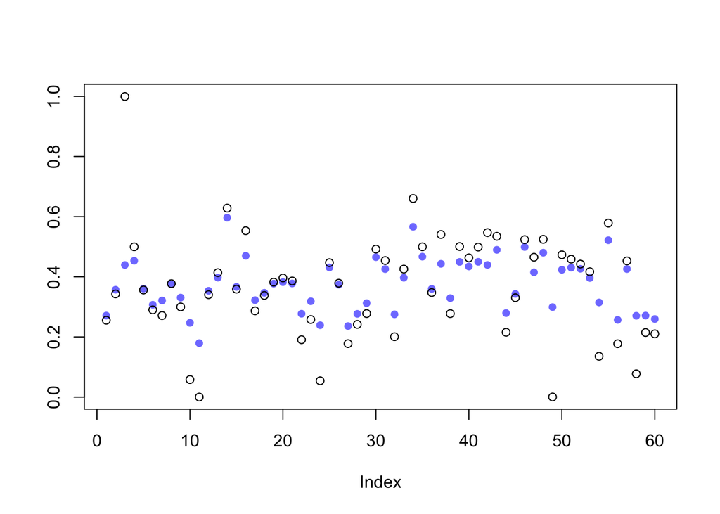

```r
post.9 <- extract.samples(m12.9)
post.10 <- extract.samples(m12.10)


plot(logistic(apply(post.9$a_district, 2, median)), col=rangi2, pch =16, ylim = c(0, 1), ylab="")
points(logistic(apply(post.10$a_district, 2, median)))
```

There’s substantial shrinkage, particularly in the cases near 0 and near 1.

###Problem 2

```r
data(Trolley)
d <- Trolley
d$factor_id <- as.integer(as.factor(d$id))

m12.11 <- map2stan(
  alist(
    response ~ dordlogit( phi , cutpoints ),
    phi <- bA*action + bC*contact + bI*intention + intercept[factor_id],
    cutpoints ~ dnorm(0,10),
    c(bA, bC, bI) ~ dnorm(0, 10),
    intercept[factor_id] ~ dnorm(0, sigma_intercept),
    sigma_intercept ~ dcauchy(0, 1)
  ),
  data=d ,
  start=list(cutpoints=c(-2,-1,0,1,2,2.5)),
  chains = 2,
  cores = 2
)
```

```
## Computing WAIC
```

```
## Constructing posterior predictions
```

```
## [ 200 / 2000 ]
[ 400 / 2000 ]
[ 600 / 2000 ]
[ 800 / 2000 ]
[ 1000 / 2000 ]
[ 1200 / 2000 ]
[ 1400 / 2000 ]
[ 1600 / 2000 ]
[ 1800 / 2000 ]
[ 2000 / 2000 ]
```

```r
precis(m12.11, depth = 2)
```

```
##                  Mean StdDev lower 0.89 upper 0.89 n_eff Rhat
## cutpoints[1]    -4.00   0.12      -4.18      -3.81   208 1.01
## cutpoints[2]    -3.07   0.11      -3.26      -2.90   197 1.02
## cutpoints[3]    -2.29   0.11      -2.48      -2.13   194 1.02
## cutpoints[4]    -0.82   0.11      -1.00      -0.64   178 1.02
## cutpoints[5]     0.22   0.11       0.04       0.39   169 1.02
## cutpoints[6]     1.63   0.11       1.45       1.80   167 1.02
## bA              -0.96   0.04      -1.03      -0.89  2854 1.00
## bC              -1.28   0.05      -1.37      -1.19  3492 1.00
## bI              -0.96   0.04      -1.02      -0.90  3845 1.00
## intercept[1]    -0.61   0.31      -1.08      -0.11   969 1.00
## intercept[2]    -1.72   0.41      -2.39      -1.05  2284 1.00
## intercept[3]    -2.95   0.42      -3.59      -2.28  2081 1.00
## intercept[4]    -0.41   0.46      -1.18       0.30  2027 1.00
## intercept[5]    -3.42   0.43      -4.09      -2.72  1689 1.00
## intercept[6]     0.61   0.32       0.05       1.07  1192 1.00
## intercept[7]    -0.51   0.31      -0.98       0.00  1323 1.00
## intercept[8]     3.88   0.49       3.11       4.63  2443 1.00
## intercept[9]    -0.89   0.31      -1.34      -0.34  1240 1.00
## intercept[10]    0.76   0.33       0.25       1.29  1433 1.00
## intercept[11]    0.56   0.34       0.03       1.11  1523 1.00
## intercept[12]    2.36   0.38       1.78       3.00  1878 1.00
## intercept[13]   -0.46   0.29      -0.92      -0.03  1114 1.00
## intercept[14]   -1.05   0.32      -1.58      -0.57  1226 1.00
## intercept[15]    1.57   0.32       1.04       2.07  1255 1.00
## intercept[16]   -1.82   0.43      -2.51      -1.16  1543 1.00
## intercept[17]    1.58   0.48       0.78       2.32  2282 1.00
## intercept[18]   -1.17   0.38      -1.77      -0.56  1806 1.00
## intercept[19]   -1.34   0.32      -1.85      -0.85  1239 1.00
## intercept[20]   -0.56   0.30      -1.03      -0.08  1012 1.00
## intercept[21]   -2.14   0.35      -2.68      -1.57  1389 1.00
## intercept[22]   -0.08   0.36      -0.64       0.51  1877 1.00
## intercept[23]   -5.18   0.57      -6.05      -4.23  2981 1.00
## intercept[24]   -1.68   0.31      -2.16      -1.16  1261 1.00
## intercept[25]   -0.69   0.33      -1.26      -0.20  1827 1.00
## intercept[26]    0.90   0.34       0.38       1.45  1036 1.00
## intercept[27]    1.09   0.45       0.34       1.78  2188 1.00
## intercept[28]   -0.84   0.34      -1.38      -0.30  1553 1.00
## intercept[29]    1.15   0.34       0.60       1.68  1764 1.00
## intercept[30]    1.61   0.31       1.12       2.10  1658 1.00
```

[output cut: 287 more lines]

```
## intercept[318]  -0.81   0.34      -1.33      -0.27  1488 1.00
## intercept[319]  -0.38   0.31      -0.86       0.13  1025 1.00
## intercept[320]  -1.75   0.35      -2.27      -1.17  1218 1.00
## intercept[321]  -1.70   0.36      -2.24      -1.13  1564 1.00
## intercept[322]   3.93   0.44       3.24       4.64  2069 1.00
## intercept[323]   0.22   0.33      -0.31       0.76  1055 1.00
## intercept[324]   5.98   0.82       4.68       7.25  3102 1.00
## intercept[325]  -1.29   0.53      -2.20      -0.49  2976 1.00
## intercept[326]   0.58   0.32       0.07       1.08  1123 1.00
## intercept[327]  -0.33   0.33      -0.84       0.20  1622 1.00
## intercept[328]   1.69   0.33       1.16       2.19  1241 1.00
## intercept[329]  -1.23   0.30      -1.70      -0.73  1214 1.00
## intercept[330]  -3.37   0.45      -4.05      -2.63  2684 1.00
## intercept[331]  -0.65   0.38      -1.22      -0.02  1367 1.00
## sigma_intercept  1.89   0.08       1.76       2.02  3289 1.00
```

```
#phi <- bA*Action + bI*Intention + bC*Contact + a_individual[factor_id] + intercept,
#a_individual[factor_id] ~ dnorm(0, sigma),
#c(bA, bI, bC, intercept) ~ dnorm(0, 10),
#sigma ~ dcauchy(0, 1),
```

```r
m12.12 <- map2stan(
  alist(
    response ~ dordlogit( phi , cutpoints ),
    phi <- bA*action + bC*contact + bI*intention,
    cutpoints ~ dnorm(0,10),
    c(bA, bC, bI) ~ dnorm(0, 10)
  ),
  data=d ,
  start=list(cutpoints=c(-2,-1,0,1,2,2.5)),
  chains = 2,
  cores = 2
)
```

```
## Computing WAIC
```

```
## Constructing posterior predictions
```

```
## [ 200 / 2000 ]
[ 400 / 2000 ]
[ 600 / 2000 ]
[ 800 / 2000 ]
[ 1000 / 2000 ]
[ 1200 / 2000 ]
[ 1400 / 2000 ]
[ 1600 / 2000 ]
[ 1800 / 2000 ]
[ 2000 / 2000 ]
```

```r
precis(m12.12, depth = 2)
```

```
##               Mean StdDev lower 0.89 upper 0.89 n_eff Rhat
## cutpoints[1] -2.84   0.05      -2.91      -2.76  1658    1
## cutpoints[2] -2.16   0.04      -2.22      -2.09  1762    1
## cutpoints[3] -1.57   0.04      -1.64      -1.51  1749    1
## cutpoints[4] -0.55   0.04      -0.61      -0.49  1729    1
## cutpoints[5]  0.12   0.04       0.06       0.18  1955    1
## cutpoints[6]  1.02   0.04       0.96       1.09  2268    1
## bA           -0.71   0.04      -0.77      -0.65  2145    1
## bC           -0.96   0.05      -1.05      -0.89  2061    1
## bI           -0.72   0.04      -0.77      -0.66  2712    1
```

```r
compare(m12.11, m12.12)
```

```
##           WAIC pWAIC  dWAIC weight     SE    dSE
## m12.11 31339.4 355.8    0.0      1 177.90     NA
## m12.12 37089.6   8.9 5750.2      0  76.21 172.57
```

The varying intercept model fits much better and has a much lowre WAIC, despite the higher degrees of freedom.

###Problem 3

```r
d$story_id <- as.integer(as.factor(d$story))

m12.13 <- map2stan(
  alist(
    response ~ dordlogit( phi , cutpoints ),
    phi <- bA*action + bC*contact + bI*intention + a_individual[factor_id] + a_story[story_id],
    cutpoints ~ dnorm(0,10),
    c(bA, bC, bI) ~ dnorm(0, 10),
    a_individual[factor_id] ~ dnorm(0, sigma_individual),
    a_story[story_id] ~ dnorm(0, sigma_story),
    sigma_individual ~ dcauchy(0, 1),
    sigma_story ~ dcauchy(0, 1)
  ),
  data=d ,
  start=list(cutpoints=c(-2,-1,0,1,2,2.5)),
  chains = 2,
  cores = 2
)
```

```
## Computing WAIC
```

```
## Constructing posterior predictions
```

```
## [ 200 / 2000 ]
[ 400 / 2000 ]
[ 600 / 2000 ]
[ 800 / 2000 ]
[ 1000 / 2000 ]
[ 1200 / 2000 ]
[ 1400 / 2000 ]
[ 1600 / 2000 ]
[ 1800 / 2000 ]
[ 2000 / 2000 ]
```

```r
precis(m12.13, depth = 2)
```

```
##                    Mean StdDev lower 0.89 upper 0.89 n_eff Rhat
## cutpoints[1]      -4.34   0.21      -4.69      -4.04   312 1.00
## cutpoints[2]      -3.37   0.20      -3.67      -3.03   308 1.01
## cutpoints[3]      -2.55   0.20      -2.87      -2.23   306 1.01
## cutpoints[4]      -1.01   0.20      -1.33      -0.71   300 1.01
## cutpoints[5]       0.07   0.20      -0.24       0.38   301 1.01
## cutpoints[6]       1.52   0.20       1.20       1.83   309 1.01
## bA                -1.24   0.05      -1.33      -1.16  2596 1.00
## bC                -1.87   0.07      -1.98      -1.75  2185 1.00
## bI                -0.93   0.05      -1.02      -0.86  4528 1.00
## a_individual[1]   -0.60   0.30      -1.07      -0.13   831 1.00
## a_individual[2]   -1.70   0.43      -2.44      -1.06  2136 1.00
## a_individual[3]   -3.04   0.43      -3.72      -2.35  2036 1.00
## a_individual[4]   -0.42   0.47      -1.21       0.29  3107 1.00
## a_individual[5]   -3.54   0.44      -4.28      -2.87  1842 1.00
## a_individual[6]    0.67   0.33       0.13       1.18  1045 1.00
## a_individual[7]   -0.43   0.31      -0.91       0.08   936 1.00
## a_individual[8]    3.96   0.51       3.12       4.74  2336 1.00
## a_individual[9]   -0.89   0.33      -1.39      -0.35   991 1.00
## a_individual[10]   0.78   0.33       0.23       1.27  1177 1.00
## a_individual[11]   0.54   0.36      -0.01       1.16  1403 1.00
## a_individual[12]   2.41   0.37       1.80       2.98  1255 1.00
## a_individual[13]  -0.46   0.31      -0.97       0.00   971 1.00
## a_individual[14]  -1.01   0.35      -1.61      -0.49  1279 1.00
## a_individual[15]   1.70   0.32       1.16       2.19  1099 1.00
## a_individual[16]  -1.88   0.41      -2.48      -1.17  2120 1.00
## a_individual[17]   1.66   0.48       0.87       2.39  2606 1.00
## a_individual[18]  -1.17   0.37      -1.75      -0.58  1330 1.00
## a_individual[19]  -1.39   0.32      -1.85      -0.86  1004 1.00
## a_individual[20]  -0.57   0.30      -1.03      -0.12   858 1.00
## a_individual[21]  -2.21   0.35      -2.76      -1.66  1065 1.00
## a_individual[22]  -0.03   0.37      -0.65       0.54  1146 1.00
## a_individual[23]  -5.39   0.63      -6.45      -4.46  2431 1.00
## a_individual[24]  -1.76   0.29      -2.22      -1.30   924 1.00
## a_individual[25]  -0.70   0.32      -1.24      -0.20   856 1.00
## a_individual[26]   0.89   0.34       0.33       1.42  1137 1.00
## a_individual[27]   1.06   0.45       0.37       1.79  1724 1.00
## a_individual[28]  -0.86   0.35      -1.43      -0.31  1611 1.00
## a_individual[29]   1.21   0.33       0.70       1.75  1153 1.00
## a_individual[30]   1.72   0.34       1.19       2.26  1316 1.00
```

[output cut: 300 more lines]

```
## a_individual[331] -0.61   0.37      -1.17       0.00  1335 1.00
## a_story[1]         1.08   0.19       0.76       1.35   483 1.00
## a_story[2]        -0.31   0.19      -0.59      -0.01   483 1.00
## a_story[3]        -0.06   0.18      -0.32       0.25   457 1.00
## a_story[4]         0.57   0.18       0.30       0.86   482 1.00
## a_story[5]        -0.21   0.19      -0.49       0.09   498 1.00
## a_story[6]        -0.06   0.19      -0.34       0.27   496 1.00
## a_story[7]        -0.60   0.19      -0.88      -0.28   550 1.00
## a_story[8]         0.18   0.18      -0.12       0.46   494 1.00
## a_story[9]        -0.55   0.19      -0.86      -0.27   467 1.00
## a_story[10]        0.84   0.19       0.57       1.16   493 1.00
## a_story[11]       -0.47   0.18      -0.76      -0.16   467 1.00
## a_story[12]       -0.39   0.18      -0.69      -0.11   476 1.00
## sigma_individual   1.96   0.08       1.82       2.09  3287 1.00
## sigma_story        0.61   0.15       0.39       0.82  1413 1.00
```

```r
compare(m12.11, m12.12, m12.13)
```

```
##           WAIC pWAIC  dWAIC weight     SE    dSE
## m12.13 30686.9 364.4    0.0      1 179.83     NA
## m12.11 31339.4 355.8  652.5      0 177.90  48.54
## m12.12 37089.6   8.9 6402.7      0  76.21 175.15
```